# Activity 12: Logistic Regression

Jerome Poblete

2026-07-09

# Fitting multiple logistic regression

## 2. Read in the species data and remove unnecessary rows with NAs.

Read in and clean the data.

```r
deer_df <- utils::read.csv("../data/ph_mouse_deer.csv")
deer_df <- deer_df[complete.cases(deer_df), ]
```

## 3. Map generation

Prepare the data needed to generate the map.

```r
################################################################################
##    Generate a map showing the species' observations localities using the
##    longitude and latitude coordinates. Check Activity 10 and use the
##    provided codes as your guide for creating the map. Export the map as a
##    PDF file.
################################################################################
library(sf)
library(terra)
library(dplyr)
```

### 3.1. Get only the data for {Balabac,Ramos,Bugsuk,Bancalan,Pandanan}, Palawan.

Filtering by Palawan is necessary as there is also Ramos, Tarlac.

```r
################################################################################
##  adm0 = country
##  adm1 = provincial
##  adm2 = municipal
##  adm3 = barangay
##
##  Note that the CSV has things like "Balabac Island" and "Ramos Island".
##  However, the shapefile only has "Balabac" and "Ramos", so fix them by
##  removing " Island" so we can actually select them from the shapefile.
################################################################################
idk    <- function(x) x |> unique() |> sapply(\(x2) sub("\\s\\w+", "", x2))
pal_sf <- sf::st_read("../data/PHL_adm/PHL_adm3.shp") |>
  dplyr::filter(NAME_1 == "Palawan", NAME_3 %in% idk(deer_df$GenLocality)) |>
  dplyr::select(geometry)
################################################################################
##  Remove outliers.
##  x = Longitude
##  y = Latitude
################################################################################
pal_ext <- terra::ext(pal_sf)
deer_df <- deer_df |>
  dplyr::filter(
    dplyr::between(Longitude, pal_ext$xmin, pal_ext$xmax),
    dplyr::between(Latitude,  pal_ext$ymin, pal_ext$ymax)) |>
  dplyr::arrange(AverageDistance)
```

### 3.2. Generate and draw the map

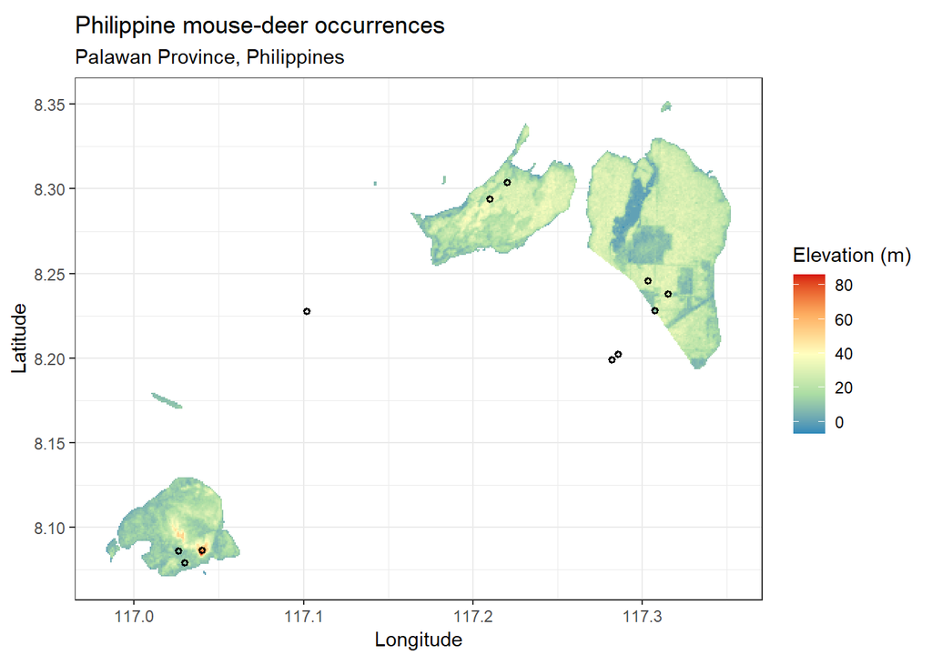

```r
library(ggplot2)
library(ggnewscale)

## Clip Philippine digital elevation model using our selected Province (Palawan).
phil_dem_spatr <- terra::rast("../data/ph_strm_geo.tif")

## Transform if needed.
pal_sf <- sf::st_transform(pal_sf, sf::st_crs(phil_dem_spatr))

## Clip raster.
pal_dem_spatr <- phil_dem_spatr |> terra::crop(pal_sf) |> terra::mask(pal_sf)

## Convert demarcation(?) data for ggplot.
names(pal_dem_spatr) <- "Elevation"

## Visualize the lowest to highest points.
pal_grad_vect <- c("#2B89BA", "#ABDDA4", "#FFFFBF", "#FDAE61", "#D71910")

################################################################################
## Plot DEM.
################################################################################
ggplot2::ggplot(terra::as.data.frame(pal_dem_spatr, xy=TRUE)) +
  ggplot2::geom_tile(aes(x, y, fill=Elevation)) +

  ## Change color manually.
  ggplot2::scale_fill_gradientn(colours=pal_grad_vect, name="Elevation (m)") +

  ## Plot sampling points as well.
  ggnewscale::new_scale_fill() +
  ggplot2::geom_point(data=deer_df, ## Override the chained implicit argument!
    mapping = aes(Longitude, Latitude),
    shape   = 21,
    colour  = "black",
    size    = 1.0,
    stroke  = 1.0) +

  ## Finalization
  ggplot2::coord_equal() +
  ggplot2::labs(title="Philippine mouse-deer occurrences",
    subtitle="Palawan Province, Philippines",
    x="Longitude", y="Latitude") +
  ggplot2::theme_bw()
```

```r
## Save the most recent ggplot (the last one!) to a PDF file.
ggplot2::ggsave("PH_Mouse_deer_map.pdf")
```

## 4. Perform multiple logistic regression.

Use the `glm` function, ensuring that the habitat types (e.g. HabitatCode) are treated as categorical variables by converting them to factors.

```r
################################################################################
##  Multiple logistic regression models the relationship between two/more (2/+)
##  predictor variables against one (1) binary (base-2) response variable.
################################################################################

x1 <- factor(deer_df$Habitat)
x2 <- deer_df$AverageDistance
y  <- deer_df$Detected

deer_glm_df <- data.frame(x1, x2, y)
deer_glm    <- stats::glm(y ~ x1 + x2, family=binomial, data=deer_glm_df)
################################################################################
##  Calculate the predicted probabilities, holding the predictor x2 constant.
##
##  Since `x1` is already a `factor`, we don't need to worry about the range of
##  values and their corresponding labels.
################################################################################
x1_df      <- data.frame(x1, x2=mean(x2))
x1_df$prob <- predict(deer_glm, newdata=x1_df, type="response")


################################################################################
##  Calculate the predicted probabilities of x2 (Average Distance), holding each
##  level of the predictor x1 (Habitat) constant.
################################################################################
predict_x2 <- function(habitat) {
  x1_orig  <- x1
  x1       <- rep(habitat, length(x2))
  df       <- data.frame(x1_orig, x1, x2)
  df$prob  <- predict(deer_glm, newdata=df, type="response")
  return(df)
}

x2_df <- data.frame(x1)
for (habitat in levels(x1)) {
  x2_df[[habitat]] <- predict_x2(habitat)
}
```

## 5. Logistic regression curve plot

After fitting the model, create a logistic regression curve plot for each independent variable used. Export the plots as PDF files.

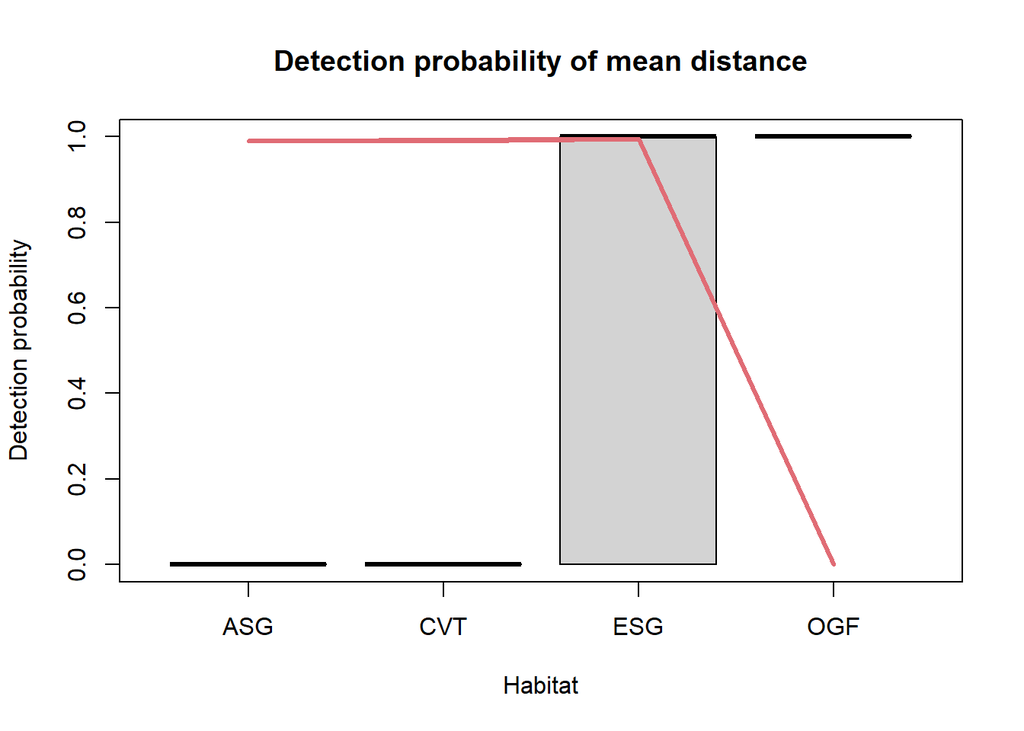

```r
library(ggplot2)

## Optional colors, I just like them more
atom_onedark <- data.frame(
  black    = "#282C34",
  lightred = "#E06C75",
  green    = "#98C379",
  yellow   = "#E5C07B",
  blue     = "#61AFEF",
  magenta  = "#C678DD",
  cyan     = "#56B6C2",
  white    = "#ABB2BF",
  darkred  = "#BE5046"
)

################################################################################
## Base R plot
################################################################################
plot(x1, y,
  pch  = 19,
  main = "Detection probability of mean distance",
  xlab = "Habitat", ylab = "Detection probability",
  ylim = c(0.0, 1.0))

## Operates on the most recently drawn plot.
## Draws the lines at corresponding coordinates given by x and y (the 1st two
## arguments).
graphics::lines(x1_df$x1, x1_df$prob, col=atom_onedark$lightred, lwd=3)
```

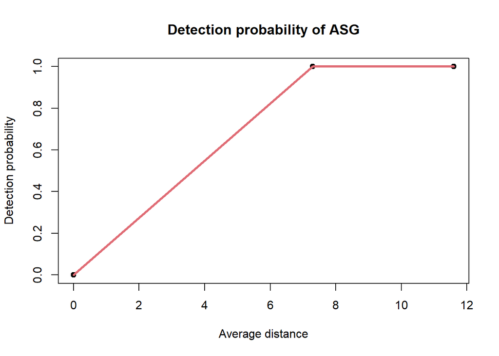

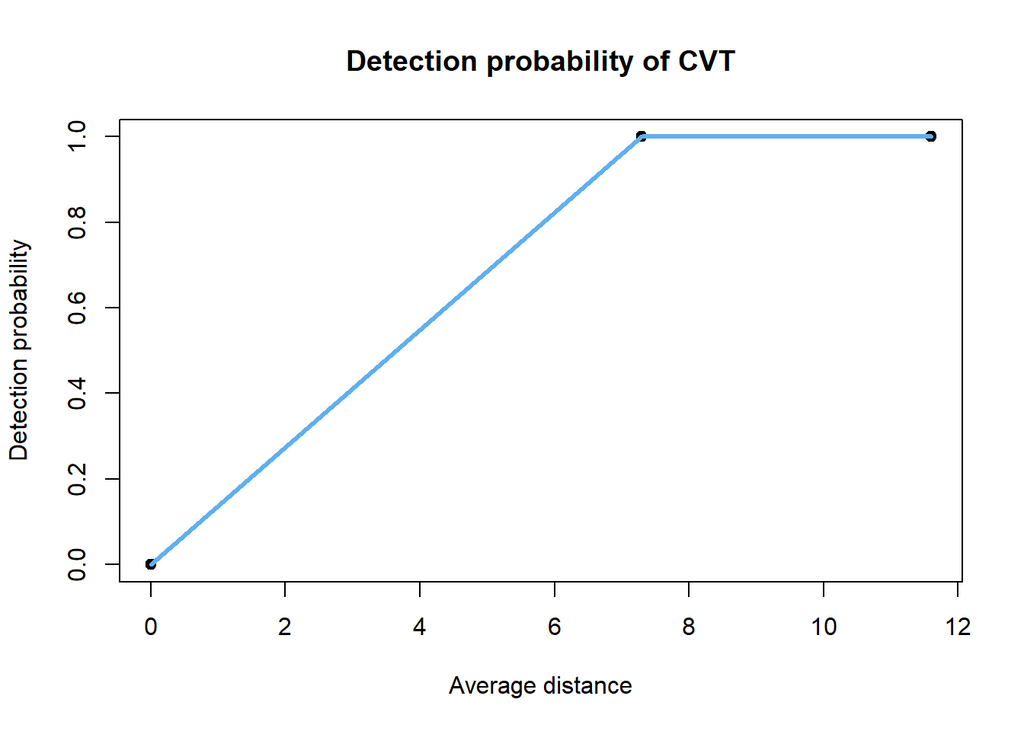

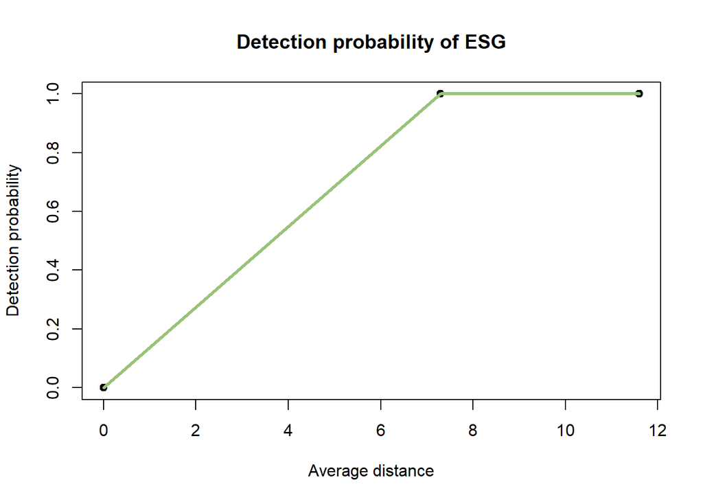

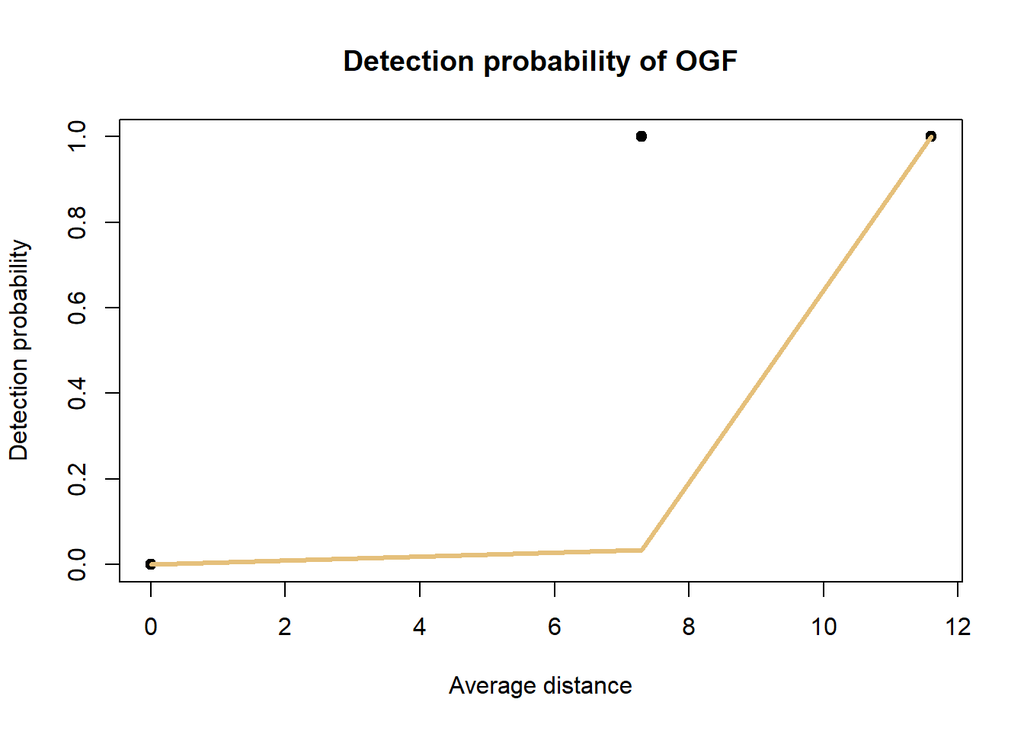

```r
level2colour <- c(
  ASG=atom_onedark$lightred,
  CVT=atom_onedark$blue,
  ESG=atom_onedark$green,
  OGF=atom_onedark$yellow)

draw_x2 <- function(habitat) {
  ## Logistic regression curve plot for Average distance, holding each habitat
  ## code constant when calculating the lines.
  plot(x2, y,
    pch  = 19,
    main = paste0("Detection probability of ", habitat),
    xlab = "Average distance", ylab = "Detection probability",
    ylim = c(0.0, 1.0))

  ## Assume data is already sorted by average distance. This ensures that the
  ## line goes only in one direction.
  df <- x2_df[[habitat]]
  x  <- df$x2
  y  <- df$prob
  graphics::lines(x, y, col=level2colour[[habitat]], lwd=3)
}

for (habitat in levels(x1)) {
  draw_x2(habitat)
}
```

## 6. Model summary output

```r
summary(deer_glm)
```

```
##
## Call:
## stats::glm(formula = y ~ x1 + x2, family = binomial, data = deer_glm_df)
##
## Coefficients:
##               Estimate Std. Error z value Pr(>|z|)
## (Intercept) -2.557e+01  1.527e+05       0        1
## x1CVT       -7.675e-14  2.160e+05       0        1
## x1ESG        6.700e-01  1.878e+05       0        1
## x1OGF       -2.690e+01  3.396e+05       0        1
## x2           6.727e+00  1.836e+04       0        1
##
## (Dispersion parameter for binomial family taken to be 1)
##
##     Null deviance: 1.5158e+01  on 10  degrees of freedom
## Residual deviance: 2.6276e-10  on  6  degrees of freedom
## AIC: 10
##
## Number of Fisher Scoring iterations: 24
```

Examination of results

### i.) Detection probability of mean distance per habitat type

Holding the average distance constant by getting its average, the plot tells us that the Philippine Mouse-deer is absent (y=0) in the ASG (x1=1) and CVT (x1=2) habitats surveyed. The deer is present in ESG (x1=3) and OGF (x1=4).

The probability line, in red, shows that, at the average of the mean distances (mean(x2)=4.49), then the habitats ASG, CVT, and ESG have almost 100% (y>0.99) detection probability while OGF has an almost 0% (y<2e-10) detection probability.

These results are interesting because both ASG and CVT have no instances of the deer recorded yet were determine to have an almost 100% detection probability. Also, OGF has one (1) instance (x2=11.6) yet has 0% detection probability. This may have to do with the fact the average (x=4.49) was what we used to hold the average distance constant. At a glance I would say that 0.0 is “closer” to 4.49 than 11.66, which may explain why the model calculated a nonzero detection probability.

### ii.) Detection probability of each habitat type per average distance

For each habitat type, each particular type was held constant when calculating the probabilities for the average distances. That is, a logistic regression curve plot was generated for Average distance x Detection probability holding one habitat type, for example ASG, constant. This process was repeated for the other habitat types with new plots.

Habitat types ASG, CVT, and ESG all resulted in the same plot. The sampling points with distances of 0.0 (x2=0.0) all had a near 0% (prob=7.88e-12) detection probability. However, at distances of 7.3 (x2=7.3) and 11.6 (x2=11.6) the detection probability was 100% (prob=1.0). Like in the previous plot, this was expected for ESG, but not for ASG and CVT.

## 7. In a Word document…

…put together all of the plots, including the map and your interpretation of results.